# Country Opportunities Report Template

# Objectives of this report

# OHI Global Framework and Tanzania

Before discussing scores, data, or data gaps, we will go through each goal of the global assessment conceptually, to determine whether these goals each represent Tanzania.

Full descriptions of each goal at [ohi-science.org/ohi-global/goals](http://ohi-science.org/ohi-global/goals.html), and a presentation to walk through each goal described in this section is available [here](https://docs.google.com/presentation/d/1R5oIFpTAqVbVTe6LymA9_eyaihOb7o3oJ9O6J5TruiE/edit?usp=sharing)

## Food Provision: Fisheries

### Goal Description

The Fisheries sub-goal describes the amount of wild-caught seafood harvested and its sustainability for human consumption. The model generally compares landings with Maximum Sustainable Yield. A score of 100 means the country or region is harvesting seafood to the ecosystem’s production potential in an sustainable manner.

## Food Provision: Mariculture

### Goal Description

Mariculture measures the ability to reach the highest levels of seafood gained from farm-raised facilities without damaging the ocean’s ability to provide fish sustainably now and in the future. Higher scores reflect high food provisioning in a sustainable manner, while not compromising the water quality in the farmed area and not relying on wild populations to feed or replenish the cultivated species. A score of 100 means that a region is sustainably harvesting the greatest amount of farmed seafood possible based on its own potential.

## Artisanal Fishing Opportunity

### Goal Description

Artisanal fishing, often also called small-scale fishing, provides a critical source of food, nutrition, poverty alleviation and livelihood opportunities for many people around the world, in particular in developing nations. This goal measure whether people who need to fish on a small, local scale have the opportunity to do so. It has three sub-components: stock, access, and need. A score of 100 means the country or region is meeting the needs of artisanal fishermen or communities by implementing institutional supports, providing access to near-shore water, and maintaining the health of targeted species.

## Natural Products

### Goal Description

In many countries the harvest of non-food natural products is important for local economies and can also be traded internationally. The sustainable harvest of these products is therefore an important component of a healthy ocean. This goal assesses the ability of countries to maximize the sustainable harvest of living marine resources, such as corals, shells, seaweeds, and fish for the aquarium trade. It does not include bioprospecting which focuses on potential (and largely unknowable and potentially infinite) value rather than current realized value, or non-living products such as oil and gas or mining products which by definition are not sustainable.

## Carbon Storage

### Goal Description

The Carbon Storage goal captures the ability of the coastal habitats to remove carbon given their carbon uptake rate and health conditions. A score of 100 means all habitats that contribute to carbon removal are still intact or have been restored and they can function to their full carbon burial potential. Highly productive coastal wetland ecosystems or seagrass store substantially large amount of carbon have the highest sequestration rates of any habitats on earth. They are also threatened by under-regulated coastal development but are amenable to restoration and conservation efforts.

## Coastal Protection

### Goal Description

This goal aims to assess the amount of protection provided by marine and coastal habitats against flooding and erosion to coastal areas that people value, both inhabited (homes and other structures) and uninhabited (parks, special places, etc.). A score of 100 would indicate that these habitats are all still intact or have been restored to their reference conditions.

## Tourism & Recreation

### Goal Description

Tourism and recreation in coastal areas is a major component of thriving coastal communities and a measure of how much people value ocean systems, i.e. by traveling to coastal and ocean areas. This goal aims to capture the number of people, and the quality of their experience, visiting coastal and marine areas and attractions. A score of 100 means a region utilizes its full recreational potential without harming the ecosystem.

## Livelihoods & Economies: Livelihoods

### Goal Description

The jobs and revenue produced from marine-related industries are clearly of huge value to many people, even for those people who do not directly participate in marine-related industries. People value community identity, tax revenue, and indirect economic and social impacts of a stable coastal economy. This sub-goal Livelihood describes job quantity and quality for people living on the coast. Livelihoods includes two equally important sub-components, the number of jobs, which is a proxy for livelihood quantity, and the per capita average annual wages, which is a proxy for job quality.

## Livelihoods & Economies: Economies

### Goal Description

Economies captures the economic value associated with marine industries using revenue from marine sectors. It is composed of a single component, revenue.

## Sense of Place: Iconic Species

### Goal Description

Iconic species are those that are relevant to local cultural identity through a species’ relationship to one or more of the following: 1) traditional activities such as fishing, hunting or commerce; 2) local ethnic or religious practices; 3) existence value; and 4) locally-recognized aesthetic value (e.g., touristic attractions/common subjects for art such as whales). Habitat-forming species are not included in this definition of iconic species, nor are species that are harvested solely for economic or utilitarian purposes (even though they may be iconic to a sector or individual). This sub-goal assesses how well those species are conserved.

## Sense of Place: Lasting Special Places

### Goal Description

Sense of Place goal tries to capture the aspects of the coastal and marine system that people value as part of their cultural identity. This definition includes people living near the ocean and those who live far from it but still derive a sense of identity or value from knowing particular places or species exist. The sub-goal of Lasting Special Places focuses on those geographic locations that hold particular value for aesthetic, spiritual, cultural, recreational or existence reasons, and assesses how well they are protected. A score of 100 means the species and places important for cultural identity are protected and conserved.

## Clean Waters

### Goal Description

People value marine waters that are free of pollution and debris for aesthetic and health reasons. Contamination of waters comes from oil spills, chemicals, eutrophication, algal blooms, disease pathogens (e.g., fecal coliform, viruses, and parasites from sewage outflow), floating trash, and mass kills of organisms due to pollution. People are sensitive to these phenomena occurring in areas that they access for recreation or other purposes as well as for simply knowing that clean waters exist. The Clean Water goal captures the degree to which local waters are unpolluted by natural and human-made causes. This goal scores highest when the contamination level is zero.

## Biodiversity: Species

### Goal Description

People value biodiversity in particular for its existence value. The risk of species extinction generates great emotional and moral concern for many people. As such, Biodiversity goal assesses the conservation status of species based on the best available global data. This sub-goal of Species assesses the health of all marine species present in a region, including endangered species and species in relatively good conditions. The presence of higher-risk species leads to a higher score.

## Biodiversity: Habitats

### Goal Description

Habitats conditions are considered as a proxy for condition of the broad suite of species that depend on them. The Habitats sub-goal includes all habitats in the study area, and assess their health condition and coverage area.

### OHI+ Tanzania

# Global Data, Data Gaps, Opportunities

## Objectives

To explore the OHI Global data for Tanzania, focusing on where data are estimated (gapfilled) instead of available in global data sets for Tanzania.

## Gapfilling in Tanzania

Let’s look a bit deeper to see numerically the percent gapfilling by goal to help us prioritize which goals we want to explore more deeply. We can pull directly from the data from the [Frazier et al. 2015](http://journals.plos.org/plosone/article?id=10.1371/journal.pone.0160377) publication.

It’s interesting to compare the percent gapfilling by goal to the scores by goal. Let’s look at this figure and discuss what we see.

### Figure: % Gapfilled vs. Status Scores

There may be a few places where there are overlaps because goals have the exact same scores.

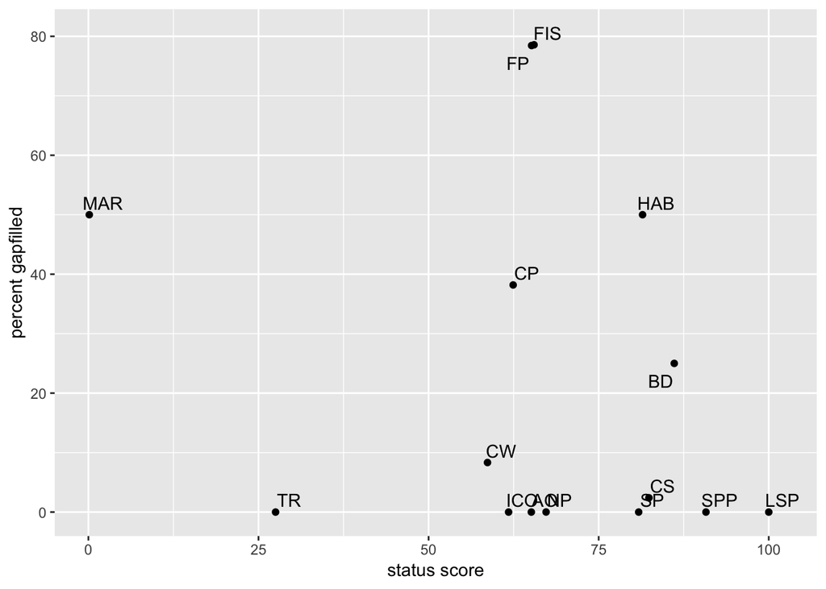

## Gapfilling Observations

Let’s brainstorm together: let’s list overall observations and observations by goal. Then we will prioritize which to dive deeply into and look at the underlying data with the time we have.

### Overall

**Observations:**

### Food Provision (FP)

**Observations**:

- if FP and FIS are plotted on top of each other, it means that the FP score is the same as FIS. This means that MAR contributes nothing to the FP score, and in fact the MAR score is 0.

### Tourism and Recreation (TR)

### Species-based goals (ICO, SPP)

### Livelihoods and Economies (LE, LIV, ECO)

**Observations**:

- The LE goal is not on the figure. We didn’t include them in our gapfilling analyses because our models rely on old data (pre-2012).

Now, where should we start? What order should we discuss these?

## Data discussion: deep dive

Let’s look into the data behind some of these goals.

We will use several resources for each goal, all linked from [ohi-science.org/ohi-global](http://ohi-science.org/ohi-global%5D):

- ohi-science.org/ohi-global/goals
- [ohi-science.org/ohi-global/layers_table](http://ohi-science.org/ohi-global/layers_table.html)
- [Global supplemental information](https://rawgit.com/OHI-Science/ohi-global/draft/global_supplement/Supplement.html)

## [Food Provision: Fisheries](http://ohi-science.org/ohi-global/goals.html#food_provision:_fisheries)

**Questions:**

- Which species are included in the FIS calculation? Where do the data come from?

#### Global Data

Global data are from the [**Sea Around Us Project**](http://www.seaaroundus.org), which does spatial allocation modeling of FAO catch. Many species do not have formal stock assessments, but they do have tons of catch through time. The criteria we use for our fisheries model is data that has:

- **catch by species**: only what is fished within Tanzania’s EEZ
- **years**: at least 10 years of data (preferably 20)

We can look at these data in several ways. Let’s start by looking on SAUP’s website at an interactive visualization of fish caught in Tanzania’s exclusive economic zone (EEZ). Here’s how:

1. Navigate to seaaroundus.org
2. Click “Tools & Data”
3. Search “Tanzania”

We can also look at the mapped locations of fishing effort by Tanzania (remember that OHI only includes catch caught withing Tanzania’s EEZ.

1. Click “Mapped Data”

Let’s look through the species listed and see if there are any included that don’t represent Tanzania’s fisheries within the EEZ.

#### Mean catch

The mean catch layer ([fis_meancatch](https://github.com/OHI-Science/tza/blob/master/global_explore/data/fis_meancatch_lookup.csv)) is in some ways a historic list because it includes species that may not be caught any more (i.e. was fished in the past and stopped for some reason). It is calculated as the average (mean) of each species’ catch through time, so if it was a big catch in the past but now is 0, it will still average (it keeps all species in the dataset).

It will be more useful for us to look at the raw catch values, and see if any of them don’t seem right. Below the scientific name is listed, with the common name (if known).

|  | stock_name | common |
| --- | --- | --- |
| 1 | Marine_fishes_not_identified |  |
| 2 | Miscellaneous_marine_crustaceans |  |
| 3 | Marine_groundfishes_not_identified |  |
| 4 | Marine_pelagic_fishes_not_identified |  |
| 5 | Mollusca |  |
| 6 | Elasmobranchii |  |
| 7 | Chondrichthyes |  |
| 8 | Cephalopoda |  |
| 9 | Bivalvia |  |
| 10 | Malacostraca |  |

[output cut: 164 more lines]

There are 174 species in the [fis_meancatch](https://github.com/OHI-Science/tza/blob/master/global_explore/data/fis_meancatch_lookup.csv) layer for Tanzania.

#### Raw catch data

To understand mean catch, dive into catch by species.

Let’s do two things. First, look through the list of species to see if any of them should be removed.

There are 178 unique species.

Do we want to look at the timeseries for any species? For example:

|  | year | taxon_scientific_name | taxon_common_name | tons | stock_id |
| --- | --- | --- | --- | --- | --- |
| 1 | 2014 | Acanthuridae | Surgeons, tangs, unicornfishes | 1516.03804598686 | Acanthuridae-51 |
| 2 | 2013 | Acanthuridae | Surgeons, tangs, unicornfishes | 1167.95462945242 | Acanthuridae-51 |
| 3 | 2012 | Acanthuridae | Surgeons, tangs, unicornfishes | 566.169179647438 | Acanthuridae-51 |
| 4 | 2011 | Acanthuridae | Surgeons, tangs, unicornfishes | 801.977429620835 | Acanthuridae-51 |
| 5 | 2010 | Acanthuridae | Surgeons, tangs, unicornfishes | 1069.73409506088 | Acanthuridae-51 |
| 6 | 2009 | Acanthuridae | Surgeons, tangs, unicornfishes | 870.35586153 | Acanthuridae-51 |
| 7 | 2008 | Acanthuridae | Surgeons, tangs, unicornfishes | 887.870276051573 | Acanthuridae-51 |
| 8 | 2007 | Acanthuridae | Surgeons, tangs, unicornfishes | 826.869119092203 | Acanthuridae-51 |
| 9 | 2006 | Acanthuridae | Surgeons, tangs, unicornfishes | 1602.68697247272 | Acanthuridae-51 |
| 10 | 2005 | Acanthuridae | Surgeons, tangs, unicornfishes | 966.067272496121 | Acanthuridae-51 |

[output cut: 55 more lines]

#### B/Bmsy

These are the species stocks that we have data for [fis_b_bmsy](https://github.com/OHI-Science/tza/blob/master/global_explore/data/fis_b_bmsy_lookup.csv):

|  | stock_name | common |
| --- | --- | --- |
| 1 | Coryphaena_hippurus | Common dolphinfish |
| 2 | Istiophorus_platypterus | Indo-Pacific sailfish |
| 3 | Auxis_rochei | Bullet tuna |
| 4 | Auxis_thazard | Frigate tuna |
| 5 | Euthynnus_affinis | Kawakawa |
| 6 | Katsuwonus_pelamis | Skipjack tuna |
| 7 | Scomberomorus_commerson | Narrowbarred Spanish mackerel |
| 8 | Thunnus_alalunga | Albacore |
| 9 | Thunnus_albacares | Yellowfin tuna |
| 10 | Thunnus_obesus | Bigeye tuna |

[output cut: 20 more lines]

There are only 30 species in the [fis_b_bmsy](https://github.com/OHI-Science/tza/blob/master/global_explore/data/fis_b_bmsy_lookup.csv) layer for Tanzania.

Let’s look at these too. Are there any species that don’t seem right?

#### Discussion

- Are there any species that don’t seem right and we should remove, for meancatch or B/Bmsy?
- There are many categories that we only have information at the genus or family levels. Do you have information for species level?

## [Food Provision: Mariculture](http://ohi-science.org/ohi-global/goals.html#food_provision:_mariculture)

**Questions:**

- How do we interpret the MAR score?

### Global Data

#### Tonnes of Harvest

Let’s look at the list of species that are represented in the MAR model as tonnes of harvest: (the [mar_harvest_tonnes](https://github.com/OHI-Science/tza/blob/master/eez/layers/mar_harvest_tonnes.csv) layer).

|  | taxa |
| --- | --- |
| 1 | Giant tiger prawn |
| 2 | Indo-Pacific swamp crab |
| 3 | Milkfish |

Let’s have a peek at the data:

|  | taxa_code | year_min | year_max | total_tonnes | mean_tonnes |
| --- | --- | --- | --- | --- | --- |
| 1 | Giant tiger prawn_847 | 2006 | 2016 | 2461 | 223.727272727273 |
| 2 | Indo-Pacific swamp crab_848 | 2005 | 2016 | 13.25 | 1.10416666666667 |
| 3 | Milkfish_849 | 2004 | 2016 | 1460.47 | 112.343846153846 |

#### Discussion

- are better data available for these species?
- are there other species that should be represented in Tanzania?

## [Lasting Special Places](http://ohi-science.org/ohi-global/goals.html#sense_of_place:_lasting_special_places)

The model measures the percentage of coastal marine protected area and protected coastline in each country, against a reference percentage. We focus only on coastal waters (within 3nmi of shore) for marine special places because it was assumed that lasting special places are primarily in coastal areas; we wanted our estimates of percent area protected to be bounded to this coastal region. For coastlines, we focused only on the first km-wide strip of land as a way to increase the likelihood that the area being protected by terrestrial parks is connected to the marine system in some way.

### Global Data

Data is from the United Nations Environment Programme - World Conservation Monitoring Centre’s World Database on Protected Areas: protectedplanet.net.

Data details:

- includes all nationally designated (e.g., National Parks, Nature Reserves)
- includes internationally recognized protected areas (e.g., UNESCO World Heritage Sites, Ramsar Wetlands of International Importance)
- includes WDPA polygons only (excludes points)
- includes status of “designated” only (excludes “proposed”)

The model measures the percentage of coastal marine protected area and protected coastline in each country, against a reference percentage (30%).

|  | year | a_prot_1km | a_prot_3nm |
| --- | --- | --- | --- |
| 1 | 2000 | 1042.25 | 2245 |
| 2 | 2001 | 1042.25 | 2245 |
| 3 | 2002 | 1042.25 | 2245 |
| 4 | 2003 | 1042.25 | 2245 |
| 5 | 2004 | 1216.75 | 4099 |
| 6 | 2005 | 1216.75 | 4099 |
| 7 | 2006 | 1216.75 | 4099 |
| 8 | 2007 | 1216.75 | 4099 |
| 9 | 2008 | 1216.75 | 4099 |
| 10 | 2009 | 1216.75 | 4099 |

[output cut: 8 more lines]

There is a lag in the WDPA database, as discussed [in this article](https://www.protectedplanet.net/c/the-lag-effect-in-the-world-database-on-protected-areas). Therefore, there may be more information available for the next global assessment.

#### Discussion

- are there other coastal or marine parks that are not accounted for?

## Habitat-based goals

**Questions:**

- Which habitats are heavily gapfilled in HAB? (Or, which are not gapfilled in CP, CS?)

### Global Data

**[Carbon Storage](http://ohi-science.org/ohi-global/goals.html#carbon_storage)**: 3 coastal habitats: mangroves, seagrasses, and salt marshes

**[Coastal Protection](http://ohi-science.org/ohi-global/goals.html#coastal_protection)**: 5 coastal habitats: mangroves, seagrasses, salt marshes, coral reefs, and sea ice

**[Habitats (BD sub-goal)](http://ohi-science.org/ohi-global/goals.html#biodiversity:_habitats)**: 6 coastal habitats: mangroves, seagrasses, salt marshes, coral reefs, sea ice, and subtidal soft-bottom habitats

All models include Habitat Extent, which is not gapfilled, and is half of the calculation. But HAB is entirely modeled with Habitat Condition, which is all gapfilled for most places.

Habitats are one of our worst data sets. CP, CS goes down by ~50% because extent is ~50% of the score and extent is not gapfilled.

#### Habitat extent

|  | rgn_id | habitat | year | km2 |
| --- | --- | --- | --- | --- |
| 1 | 202 | mangrove | 2015 | 485.418822 |
| 2 | 202 | mangrove_inland1km | 2015 | 270.670991 |
| 3 | 202 | mangrove_offshore | 2015 | 61.149969 |
| 4 | 202 | seagrass | 2012 | 41.0428 |
| 5 | 202 | coral | 2012 | 1559.63 |
| 6 | 202 | soft_bottom | 2012 | 16765.5423884535 |

#### Habitat health

Let’s have a look at the data included for Tanzania:

|  | rgn_id | habitat | year | health |
| --- | --- | --- | --- | --- |
| 1 | 202 | mangrove | 2012 | 0.822368421052632 |
| 2 | 202 | seagrass | 2012 | 0.855116269050631 |
| 3 | 202 | coral | 2012 | 0.580673354488477 |
| 4 | 202 | soft_bottom | 2003 | 1 |
| 5 | 202 | soft_bottom | 2004 | 1 |
| 6 | 202 | soft_bottom | 2005 | 1 |
| 7 | 202 | soft_bottom | 2006 | 1 |
| 8 | 202 | soft_bottom | 2007 | 1 |
| 9 | 202 | soft_bottom | 2008 | 1 |
| 10 | 202 | soft_bottom | 2009 | 1 |

[output cut: 5 more lines]

#### Discussion

- Are there better data available?
- Should we look into the gapfilling question more?

## [Tourism & Recreation](http://ohi-science.org/ohi-global/goals.html#tourism__recreation)

## [Natural Products](http://ohi-science.org/ohi-global/goals.html#natural_products)

### Global Data

Which Natural Products are included for Tanzania?

|  | commodity | product |
| --- | --- | --- |
| 1 | Fish body oils, nei | fish_oil |
| 2 | Ornamental fish nei | ornamentals |
| 3 | Other seaweeds and aquatic plants and products thereof | seaweeds |
| 4 | Miscellaneous corals and shells | shells |
| 5 | Natural sponges nei | sponges |

So there are 5 NP products included.

We can also look at how much of this was gapfilled:

|  | commodity | product | year | gapfill |
| --- | --- | --- | --- | --- |
| 1 | Fish body oils, nei | fish_oil | 1997 | none |
| 2 | Fish body oils, nei | fish_oil | 1998 | none |
| 3 | Fish body oils, nei | fish_oil | 1999 | zerofill |
| 4 | Fish body oils, nei | fish_oil | 2000 | zerofill |
| 5 | Fish body oils, nei | fish_oil | 2001 | zerofill |
| 6 | Fish body oils, nei | fish_oil | 2002 | zerofill |
| 7 | Fish body oils, nei | fish_oil | 2003 | zerofill |
| 8 | Fish body oils, nei | fish_oil | 2004 | zerofill |
| 9 | Fish body oils, nei | fish_oil | 2005 | zerofill |
| 10 | Fish body oils, nei | fish_oil | 2006 | zerofill |

[output cut: 72 more lines]

#### Discussion

- are there other products that should be included?
- is this a goal that represents Tanzania well?

## Species-based goals

### Global data

**[Iconic Species subgoal of Sense of Place](http://ohi-science.org/ohi-global/goals.html#sense_of_place:_iconic_species)**: There are 17 unique species included

For Species, there are probably more than we can go through today. But, here is a table that has the full list:

|  | comname | sciname |
| --- | --- | --- |
| 1 |  | Agonostomus telfairii |
| 2 |  | Birgus latro |
| 3 |  | Butis butis |
| 4 | Humphead wrasse, Napoleon Wrasse | Cheilinus undulatus |
| 5 | Leatherback Turtle | Dermochelys coriacea |
| 6 |  | Dunckerocampus dactyliophorus |
| 7 |  | Eurypegasus draconis |
| 8 |  | Psammogobius biocellatus |
| 9 |  | Hippocampus camelopardalis |
| 10 |  | Hippocampus histrix |

[output cut: 5417 more lines]

It might be more manageable to work with the Iconic Species list:

|  | comname | sciname |
| --- | --- | --- |
| 1 | Thresher Shark | Alopias vulpinus |
| 2 | Blue whale | Balaenoptera musculus |
| 3 | Blacktip reef shark | Carcharhinus melanopterus |
| 4 | Great White Shark | Carcharodon carcharias |
| 5 | Loggerhead Turtle | Caretta caretta |
| 6 | Humphead wrasse, Napoleon Wrasse | Cheilinus undulatus |
| 7 | Green Turtle | Chelonia mydas |
| 8 | Leatherback Turtle | Dermochelys coriacea |
| 9 | Hawksbill Turtle | Eretmochelys imbricata |
| 10 | Tiger Shark | Galeocerdo cuvier |

[output cut: 7 more lines]

# Potential Assessment Regions

Global assessments assess the exclusive economic zone (EEZs) of coastal countries and territories ([see Global Supplemental Information](https://rawgit.com/OHI-Science/ohi-global/draft/global_supplement/Supplement.html#3_regions)).